# IsoPath Workflow Walkthrough

Noah Motz, Brendan Campbell, Rileigh Hudock, Tess Avery, Ben Marsaly, Howard Townsend, Jim Vasslides, Edward Hale, Aaron Carlisle

2025-12-03

## Setup Workspace

```r
# clear workspace
rm(list = ls())

# set seed
set.seed(22)

# load required packages
library(IsoPath)

# load data
iso_data = data
```

## Obtaining Diet Estimates using *simmr*

In this section, we will utilize functions from both *IsoPath* and *simmr* to take the isotope data from “iso_data” and run it through *simmr*. Since most *Rpath* models will have many functional groups, an example loop is provided to simplify the process. Prior to the loop, each predator within the model that we will estimate diets for with SIA are written out in “predator_list”, and the corresponding prey items that are to be included in *simmr* are created in “prey_list”. In this step it is crucial that the names match exactly to those in the isotope dataframe (iso_data), and that the positions in predator_list and prey_list are the same relative to each other. For example, AnchovyJuv is the first functional group in predator_list, so their diet is the first one in prey_list. The loop at the end will run each predator through *simmr* and obtain diet estimates for each. For further details on *simmr* please see Govan E, Parnell A (2019). simmr: A Stable Isotope Mixing Model. R package version 0.5.1.216, https://CRAN.R-project.org/package=simmr. The function “format_simmr_data” is from *IsoPath* and will pull all the information from “iso_data” needed for *simmr*, avoiding the need to have a seperate file for each predator. The diet form each will be saved as a *simmr* object that will be used later.

```r
# list of species that needs simmr
predator_list = c("AnchovyJuv", "BenthicInverts", "BlueCrab", "Fundulus", "MudSnail", "Oyster", "Silverside",
                  "Spot")
# list of diets for each predator
prey_list = list(
  c("Phytoplankton", "Zooplankton", "Detritus", "MudSnail"), # diet for AnchovyJuv
  c("Phytoplankton","Zooplankton", "BenthicAlg", "Ulva","Detritus"), # diet for BenthicInverts
  c("BenthicAlg", "Ulva","Detritus", "BenthicInverts", "MudSnail", "AnchovyJuv", "Silverside", "Fundulus"), # diet for BlueCrab
  c("Zooplankton","Detritus", "BenthicAlg", "Ulva","BenthicInverts", "MudSnail", "Silverside", "AnchovyJuv"), #diet for fundulus
  c("BenthicAlg", "Ulva", "Detritus"), # diet for mudsnail
  c("Phytoplankton", "Detritus"), # diet for oyster
  c("Zooplankton", "Detritus", "BenthicInverts", "MudSnail"), # diet for Silverside
  c("Zooplankton","Detritus", "BenthicInverts", "MudSnail") # diet for spot
)

# pass diets and species to simmr and run simmr
for (i in 1:length(predator_list)){
  print("=====================================================================")
  print(predator_list[i])
  # create simmr object
  simmr_object = format_simmr_data(data = iso_data, species.column = "Functional_Group",
                                   d13C.column = "d13C", d15N.column = "d15N",
                                   consumer.names = predator_list[i],
                                   prey.names = prey_list[[i]],
                                   disc.factors.c = 0.4, disc.factors.n = 3.4,
                                   disc.factors.c.sd = 1, disc.factors.n.sd = 1.3)
  # run simmr
  simmr.out = simmr_mcmc(simmr_object, mcmc_control = list(iter = 10000, burn = 1000, thin = 10, n.chain = 4))
  # check diagnostics
  summary(simmr.out, type = "diagnostics")
  # if prey_list has BenthicAlg then combine sources here below
  if (grepl("BenthicAlg", prey_list[i])){
    # combine sources
    simmr.out.post =
      combine_sources(simmr.out,
                      to_combine = c("Ulva", "BenthicAlg"),
                      new_source_name = "BenthicAlgae")
    # check diagnostics
    summary(simmr.out.post, type = "diagnostics")
    # save output
    assign(paste0("simmr_", predator_list[i]), simmr.out.post)
  } else{
    # save simmr output with predator name
    assign(paste0("simmr_", predator_list[i]), simmr.out)
  }
}
```

## Set up Basic *Rpath* Parameters

This section will input the basic Ecopath parameters into an *Rpath* object so the model can be run later. For more information on how to utilize and import data into *Rpath*, please see Aydin K, Lucey S, Gaichas S (2024). Rpath: R implementation of Ecopath with Ecosim. R package version 0.9.1, https://github.com/NOAA-EDAB/Rpath. and https://doi.org/10.1016/j.ecolmodel.2020.109057. In this step, it is important that the group names in “groups” match those that were used in the *simmr* model so the data can be transfered later.

```r
# create vector of group names
groups = c('Phytoplankton', 'BenthicAlgae', 'Oyster', 'Zooplankton','MudSnail', 'BenthicInverts', 'AnchovyJuv',
           'Silverside', 'Fundulus', 'Spot','BlueCrab', 'Detritus', 'Fishing')

# create vector of group types
# 0 - living, 1 - primary producer, 2 - detritus, 3 - fishing fleet
types = c(1, 1, 0, 0, 0, 0, 0, 0, 0, 0, 0, 2, 3)

# create rpath parameter file
REco.params = create.rpath.params(group = groups, type = types)

# biomass and parameter values for model
# biomass
biomass = c(NA, # phytoplankton
            NA, # benthicalgae
            8.1157, # oyster
            NA, # zooplankton
            NA, # mud snail
            NA, # benthic inverts
            2.04247261, # anchovy and juveniles
            6.24915461, # silversides
            9.99594211, # fundulus
            0.97389422, # spot
            6.03273367, # blue crab
            NA, # detritus
            NA) # fishing

# P/B
pb = c(160, # phytoplankton
       80, #benthic algae
       0.63, # oysters
       25, # zooplankton
       2, # mudsnail
       2, # benthic inverts
       3.12, # anchovy and juveniles changed back from 3.1
       1, # silversides
       1.2, # fundulus
       0.9, # spot
       1.21, # blue crab
       NA, # detritus
       NA) # fishing

# Q/B
qb = c(NA, # phytoplankton
       NA, # benthic algae
       2, # oysters
       83.33, # zooplankton
       10, # mudsnail
       10, # benthic inverts
       9.7, # anchovy and juveniles
       4, # silversides
       3.65, # fundulus
       6.2, # spot
       4, # blue crab
       NA, # detritus
       NA) # fishing

# assign values to rpath parameter
REco.params$model[, Biomass := biomass]
REco.params$model[, PB := pb]
REco.params$model[, QB := qb]

# EE for groups without biomass
REco.params$model[Group == 'Phytoplankton', EE := 0.95]
REco.params$model[Group == 'Zooplankton', EE := 0.95]
REco.params$model[Group == 'BenthicAlgae', EE := 0.899]
REco.params$model[Group == 'Oyster', EE := 0]
REco.params$model[Group == 'MudSnail', EE := 0.9]
REco.params$model[Group == 'BenthicInverts', EE := 0.9]

#Biomass accumulation and unassimilated consumption
REco.params$model[, BioAcc  := c(rep(0, 12), rep(NA, 1))]
REco.params$model[, Unassim := c(rep(0, 2), rep(0.2, 10), rep(NA, 1))]

#Detrital Fate
REco.params$model[, Detritus := c(rep(1, 11), rep(0, 2))]

# fisheries landings and discards (assuming 0 here)
# create landings and discards object
land = c(rep(0, 12), rep(NA, 1))
disc = c(rep(0, 12), rep(NA, 1))

# assign them to the rpath model
REco.params$model[, Fishing := land]
REco.params$model[, Fishing.disc := disc]
```

## Obtain the diet estimates from the *simmr* models

This section will pull out the average diet from the *simmr* outputs to pass these to *Rpath* for the intial model run. First, a list called “simmr_list” is made of all the *simmr* outputs generated in the initial for loop. Then, this for loop will use the simmr_diet_output_mean function from *IsoPath* to make the diet information from *simmr* in the correct format to pass to *Rpath*. The final step of the loop will save this output to be put into *Rpath* later.

```r
# make list of simmr objects
simmr_list = list(simmr_AnchovyJuv, simmr_BenthicInverts, simmr_BlueCrab, simmr_Fundulus, simmr_MudSnail,
                  simmr_Oyster, simmr_Silverside, simmr_Spot)

# pull out means from each of the simmr objects
for (i in 1:length(simmr_list)){
  # function to pull out means
  simmr.diet = simmr_diet_output_mean(simmr_list[[i]], groups)
  # save simmr output with predator name
  assign(paste0("diet_", predator_list[i]), simmr.diet)
}
```

## Pass the diets into *Rpath* and run the intial *Rpath* model

```r
# input diets for each species
REco.params$diet[, AnchovyJuv := c(diet_AnchovyJuv)]
REco.params$diet[, Fundulus := c(diet_Fundulus)]
REco.params$diet[, BlueCrab := c(diet_BlueCrab)]
REco.params$diet[, MudSnail := c(diet_MudSnail)]
REco.params$diet[, BenthicInverts := c(diet_BenthicInverts)]
REco.params$diet[, Oyster := c(diet_Oyster)]
REco.params$diet[, Silverside := c(diet_Silverside)]
REco.params$diet[, Spot := c(diet_Spot)]
REco.params$diet[, Zooplankton := c(1, rep(0, 11), NA)]

# run Rpath
# base run to check balance
REco = rpath(REco.params, eco.name = "Oyster Reef_SIA")
REco
```

```
## Rpath model: Oyster Reef_SIA
## Model Area: 1
##      Status: Balanced
##                         Group type       TL     Biomass     PB    QB        EE
## Phytoplankton   Phytoplankton    1 1.000000   1.2808125 160.00  0.00 0.9500000
## BenthicAlgae     BenthicAlgae    1 1.000000   0.9087905  80.00  0.00 0.8990000
## Oyster                 Oyster    0 2.000000   8.1157000   0.63  2.00 0.0000000
## Zooplankton       Zooplankton    0 2.000000   1.8895326  25.00 83.33 0.9500000
## MudSnail             MudSnail    0 2.000000   5.1012942   2.00 10.00 0.9000000
## BenthicInverts BenthicInverts    0 2.085338   6.8869013   2.00 10.00 0.9000000
## AnchovyJuv         AnchovyJuv    0 2.868161   2.0424726   3.12  9.70 0.7196673
## Silverside         Silverside    0 2.908008   6.2491546   1.00  4.00 0.7988973
## Fundulus             Fundulus    0 2.581498   9.9959421   1.20  3.65 0.1692222
## Spot                     Spot    0 2.801146   0.9738942   0.90  6.20 0.0000000
## BlueCrab             BlueCrab    0 2.704018   6.0327337   1.21  4.00 0.0000000
## Detritus             Detritus    2 1.000000 259.3054287   0.50  0.00 0.5161770
## Fishing               Fishing    3 1.000000   0.0000000   0.00  0.00 0.0000000
##                       GE Removals
## Phytoplankton  0.0000000        0
## BenthicAlgae   0.0000000        0
## Oyster         0.3150000        0
## Zooplankton    0.3000120        0
## MudSnail       0.2000000        0
## BenthicInverts 0.2000000        0
## AnchovyJuv     0.3216495        0
## Silverside     0.2500000        0
## Fundulus       0.3287671        0
## Spot           0.1451613        0
## BlueCrab       0.3025000        0
## Detritus       0.0000000        0
## Fishing        0.0000000        0
```

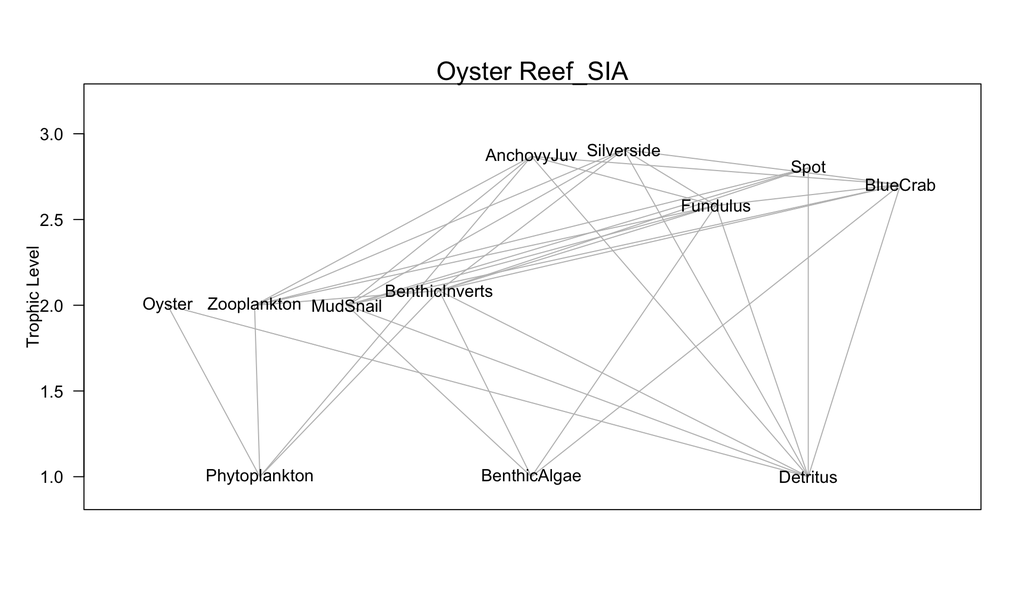

```r
# make webplot
webplot(REco, labels = T)
```

## Test diet sensitivity

One advantage of using Bayesian mixing models, such as *simmr*, is the probable distrubution of diets obtained. In this step, we will resample 1000 diets within the 95% confidence intervals from *simmr* (this percentage and number of diets can be adjusted if desired). This will be done using “simmr_diet_output_dist” to pull the confidence intervals from *simmr* (edit the CI in this function if desired), and then “diet_resample” to generate 1000 possible diets within this range (edit the number of diets in this function if desired). The “diet_resample” function is designed to always sample diets that add up to 100% so the diets can be passed to *Rpath* without issue. The 1000 diets are saved at the end of the loop and aggregated into their own list at the end of this chunk.

```r
# obtain diet distribution
for (i in 1:length(simmr_list)) {
  # make list of the distribution
  simmr.dist = simmr_diet_output_dist(simmr_list[[i]], groups)
  # resample within the distribution
  resample.diet = diet_resample(simmr.dist)
  # save the output
  assign(paste0("resample_", predator_list[i]), resample.diet)
}

# make list of resampled diets
resample_data_list <- list(
  AnchovyJuv = resample_AnchovyJuv,
  BenthicInverts = resample_BenthicInverts,
  BlueCrab = resample_BlueCrab,
  Fundulus = resample_Fundulus,
  MudSnail = resample_MudSnail,
  Silverside = resample_Silverside,
  Oyster = resample_Oyster,
  Spot = resample_Spot
)
```

## Run *Rpath* for each of the diets generated

This next code will run an *Rpath* for each 1000 possible diets created for each functional group created in the previous section and saved in “resample_data_list”. This will be done using the “diet_sensitivity_test” function which is designed to run *Rpath* for all the diets included in the input list. If the diet combinations result in a non-balanced model, the information is discarded, but if the model is balanced the trophic level estimate for each functional group is saved, called “resamped.TL” in this example.

```r
# pass diets to rpath and examine sensitivity
resampled.TL = diet_sensitivity_test(resample_data_list, REco.params)
resampled.bio = diet_sensitivity_test(resample_data_list, REco.params, metric = "biomass")
```

```r
# check how many models were balanced
sum(!is.na(resampled.TL$Phytoplankton))
```

```
## [1] 486
```

```r
# table of all trophic level means and sds
trophic.summaries = lapply(resampled.TL, function(x){
  list(
      Mean = mean(x, na.rm = TRUE),
      SD = sd(x, na.rm = TRUE)
  )
})

summary.troph = do.call(rbind, lapply(names(trophic.summaries), function(name){
  data.frame(
    Functional.Group = name,
    Mean.TL = trophic.summaries[[name]]$Mean,
    SD.TL = trophic.summaries[[name]]$SD
  )
}))

print(summary.troph)
```

```
##    Functional.Group  Mean.TL        SD.TL
## 1     Phytoplankton 1.000000 0.000000e+00
## 2      BenthicAlgae 1.000000 0.000000e+00
## 3            Oyster 2.000000 9.229162e-07
## 4       Zooplankton 2.000000 0.000000e+00
## 5          MudSnail 2.000000 9.199542e-07
## 6    BenthicInverts 2.124772 5.632231e-02
## 7        AnchovyJuv 2.854804 4.537191e-02
## 8        Silverside 2.920082 3.976710e-02
## 9          Fundulus 2.611475 1.063490e-01
## 10             Spot 2.835307 1.089541e-01
## 11         BlueCrab 2.772624 1.431302e-01
## 12         Detritus 1.000000 0.000000e+00
## 13          Fishing 1.000000 0.000000e+00
```

## Visualize how changes in diet alter the *Rpath* model

This section will use the information saved in “resampled.TL” to visualize how the trophic levels changed with different diets. This will be done using the “diet_visualization” function and this can create histograms, boxplots, or violin plots depending on the input for plot_type. A separate histogram will be created for each functional group in the model, but all groups will be put on the same box/violin plot. Additionally, specific groups to plot can be specified using species_list. This will be very helpful in large models where only a few functional groups are of interest. If no species are specified, all functional groups will be plotted. For biomass, we inlcude the groups were the biomass is estimated by Rpath including: Phytoplankton, Zooplankton, Benthic Algae, Benthic Invertebrates, Mud Snail, and Detritus.

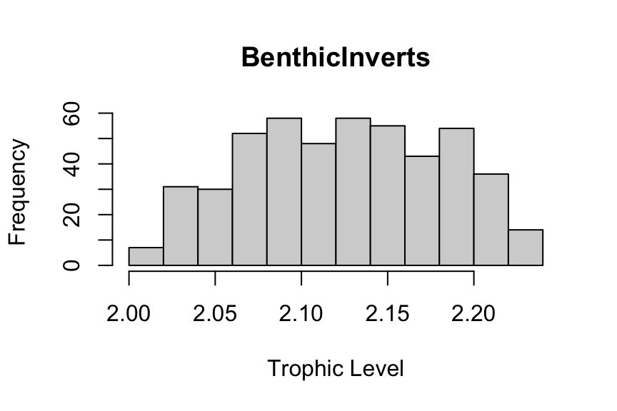

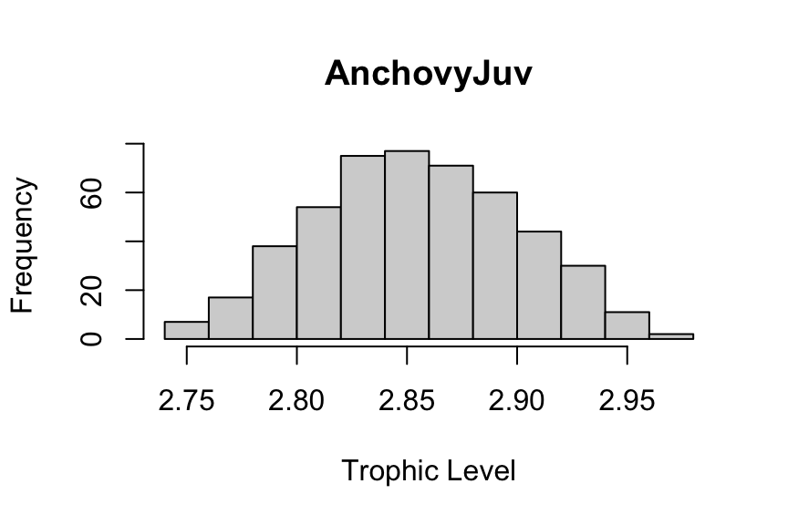

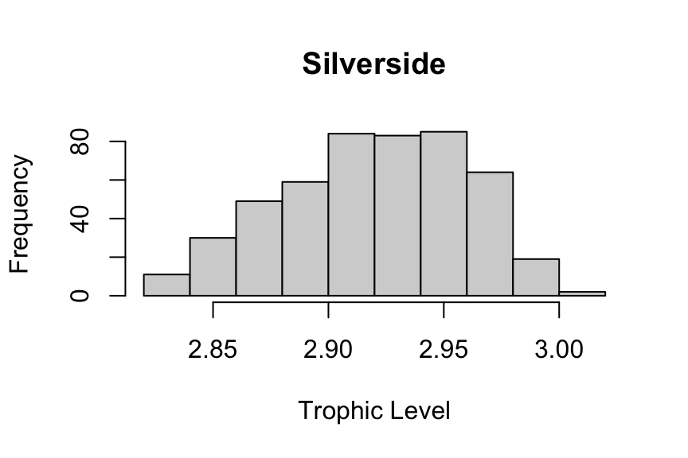

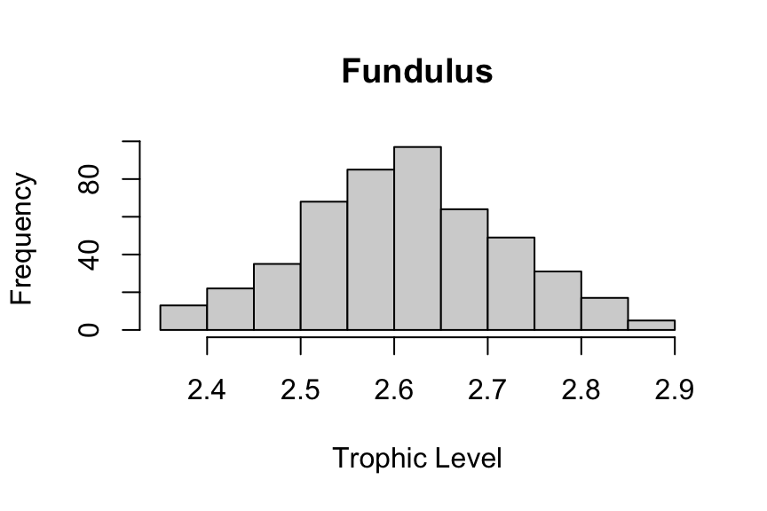

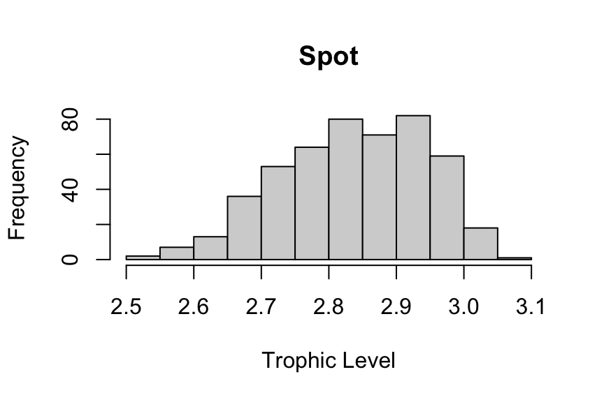

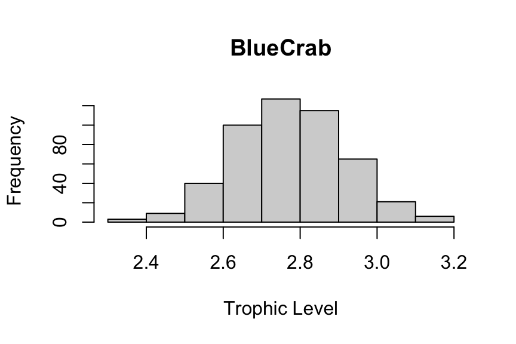

```r
## Trophic Level
# make histograms
diet_visualization(resampled.TL, plot.type = "histogram",
                   species.list = c("BenthicInverts", "AnchovyJuv",
                                    "Silverside", "Fundulus", "Spot", "BlueCrab"),
                   metric = "trophic level")
```

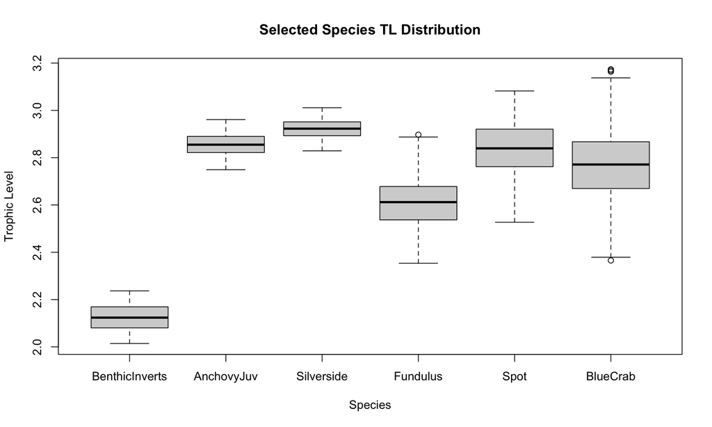

```r
# make boxplot
diet_visualization(resampled.TL, plot.type = "boxplot",
                   species.list = c("BenthicInverts", "AnchovyJuv",
                                    "Silverside", "Fundulus", "Spot", "BlueCrab"))
```

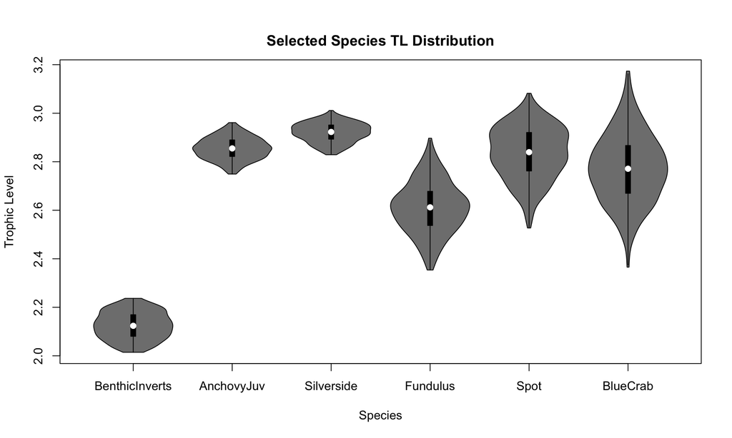

```r
# make violin plot
diet_visualization(resampled.TL, plot.type = "violin",
                   species.list = c("BenthicInverts", "AnchovyJuv",
                                    "Silverside", "Fundulus", "Spot", "BlueCrab"))
```

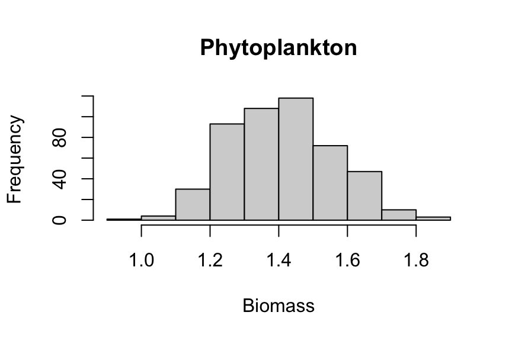

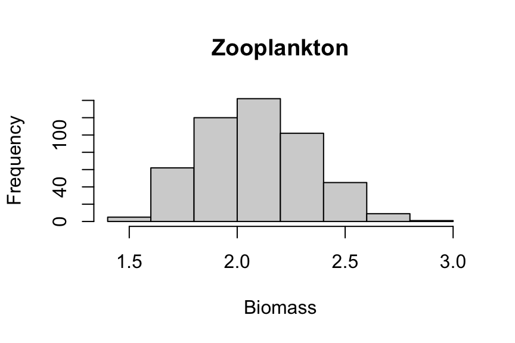

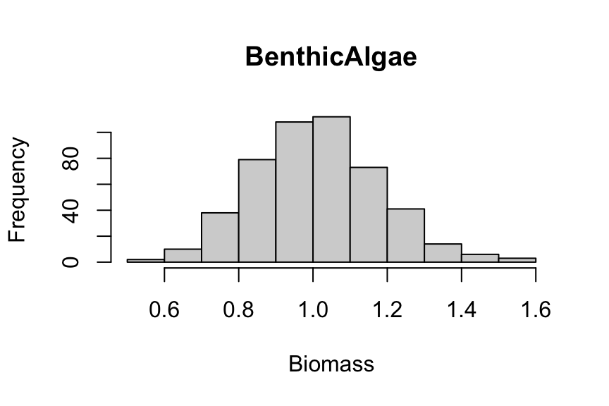

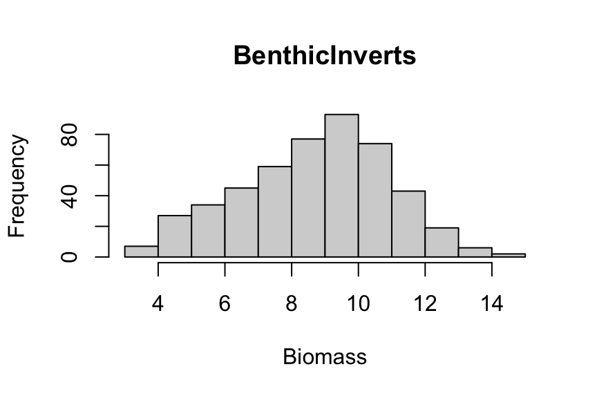

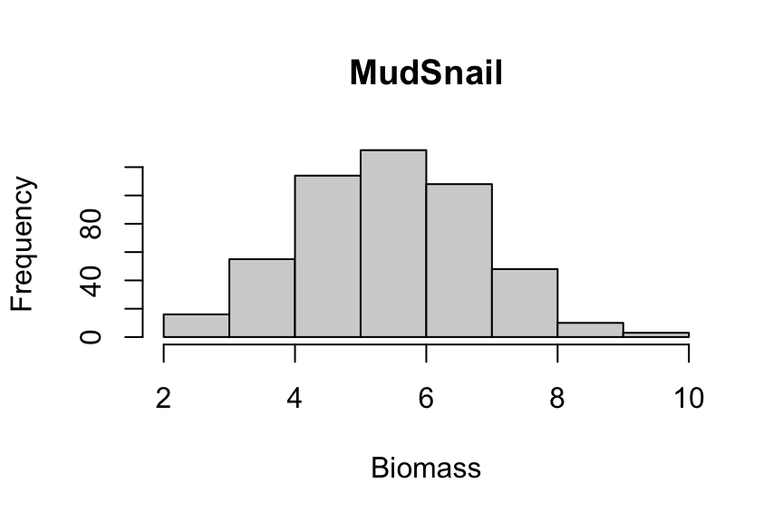

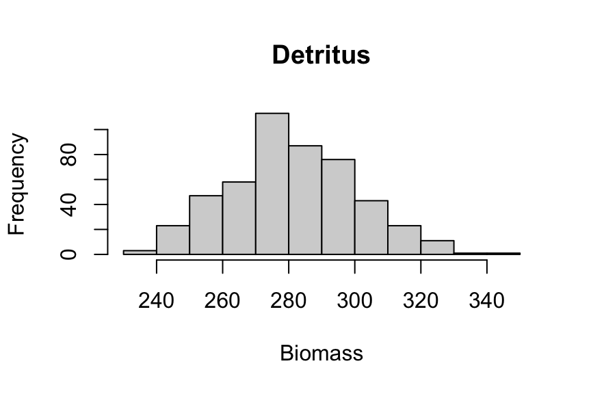

```r
## Biomass
# make histograms
diet_visualization(resampled.bio, plot.type = "histogram",
                   species.list = c("Phytoplankton", "Zooplankton", "BenthicAlgae",
                                    "BenthicInverts", "MudSnail", "Detritus"),
                   metric = "biomass")
```

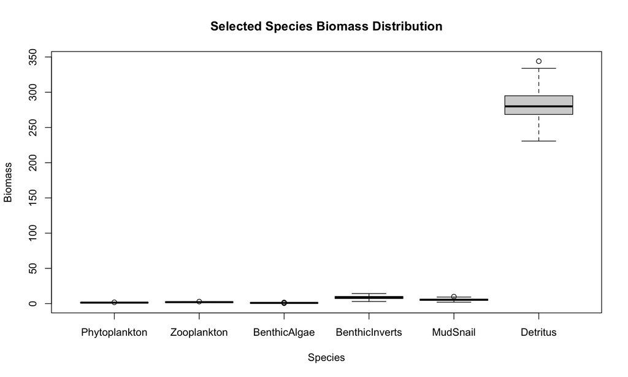

```r
# make boxplot
diet_visualization(resampled.bio, plot.type = "boxplot",
                   species.list = c("Phytoplankton", "Zooplankton", "BenthicAlgae",
                                    "BenthicInverts", "MudSnail", "Detritus"),
                   metric = "biomass")
```

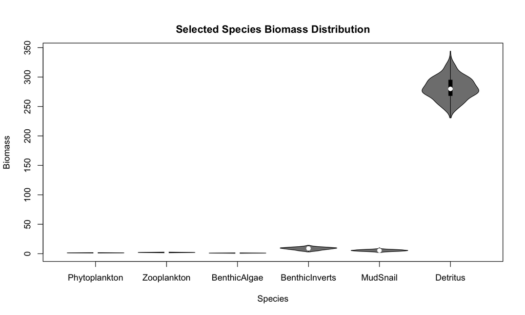

```r
# make violin plot
diet_visualization(resampled.bio, plot.type = "violin",
                   species.list = c("Phytoplankton", "Zooplankton", "BenthicAlgae",
                                    "BenthicInverts", "MudSnail", "Detritus"),
                   metric = "biomass")
```